# Data 624 Homework 3

Steven Gonzalez

2/23/2025

## Load Packages

```r
library(fpp3)
library(seasonal)
library(USgas)
```

## Exercise 1

Produce forecasts for the following series using whichever of NAIVE(y), SNAIVE(y) or RW(y ~ drift()) is more appropriate in each case:

Australian Population (global_economy) Bricks (aus_production) NSW Lambs (aus_livestock) Household wealth (hh_budget). Australian takeaway food turnover (aus_retail).

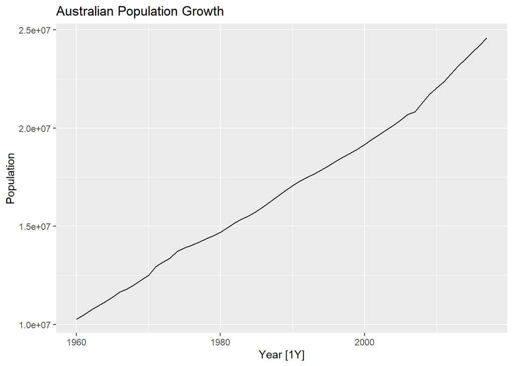

```r
aus_pop <- global_economy %>%
  filter(!is.na(Population)) %>%
  filter(Country == "Australia") %>%
  select(Population)

autoplot(aus_pop) +
  labs(title = "Australian Population Growth")
```

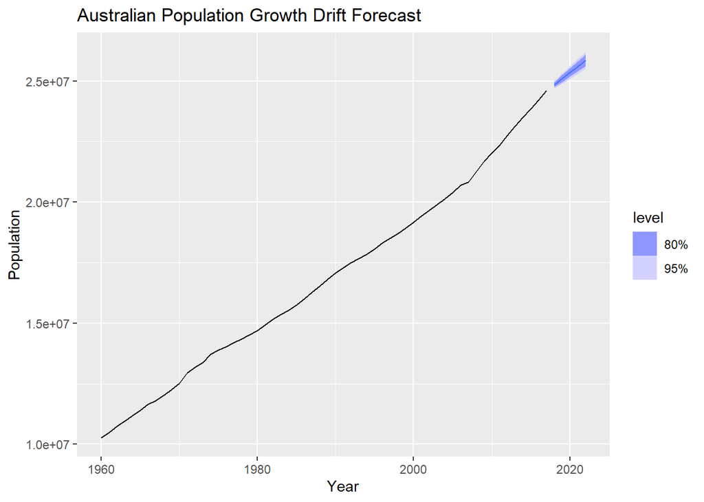

```r
aus_pop %>%
  model(Drift = RW(Population ~ drift())) %>%
  forecast(h = "5 years") %>%
  autoplot(aus_pop) +
  labs(title = "Australian Population Growth Drift Forecast")
```

The above forecast for Australian Population from `global_economy` was created using `RW(y ~ drift())`. The reason for using this technique over `NAIVE(y)` and `SNAIVE(y)` was due to the series’ already existing, and consistent, positive trend and lack of seasonality rendering other techniques useless.

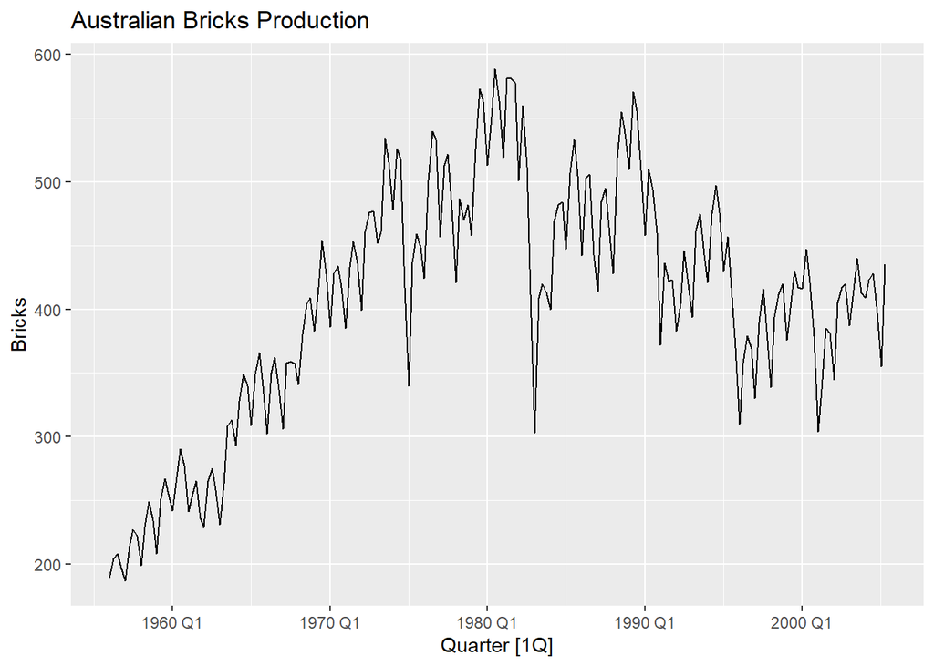

```r
bricks_pro <- aus_production %>%
  filter(!is.na(Bricks)) %>%
  select(Bricks)

autoplot(bricks_pro) +
  labs(title = "Australian Bricks Production")
```

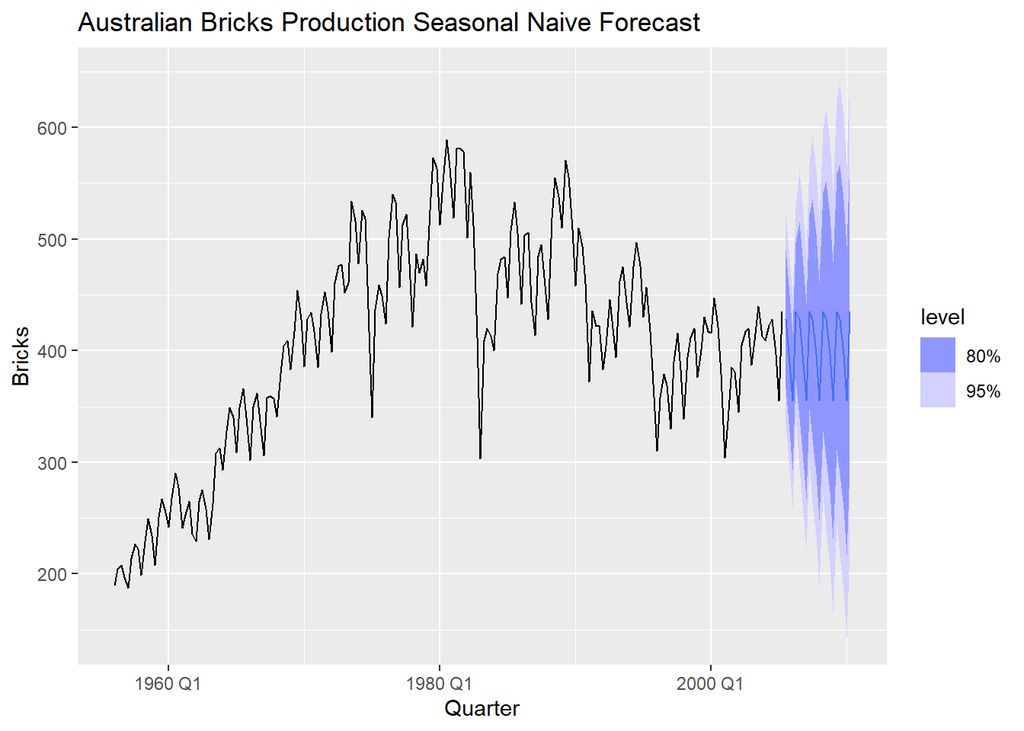

```r
bricks_pro %>%
  model(Snaive = SNAIVE(Bricks)) %>%
  forecast(h = "5 years") %>%
  autoplot(bricks_pro) +
  labs(title = "Australian Bricks Production Seasonal Naive Forecast")
```

The above forecast for Bricks from `aus_production` was created using `SNAIVE(y)`. Highly repetitive and seasonal data such as the one found in this series is best predicted with seasonality in mind. In addition, the confidence interval seen in the graph can also account for any upward or downward fluctuation that can take place in series’ trend.

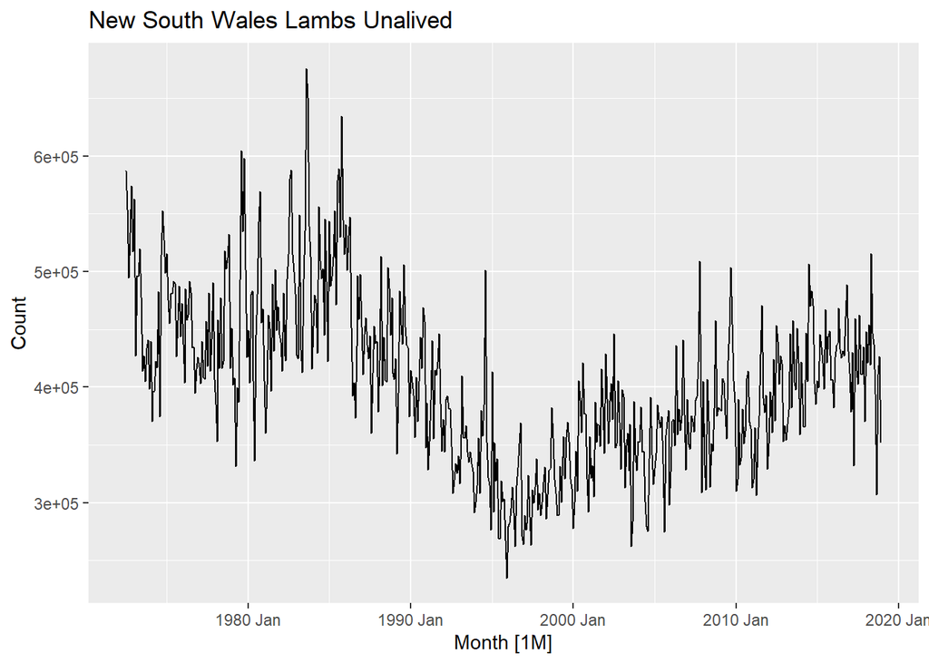

```r
nsw_lambs <- aus_livestock %>%
  filter(!is.na(Count)) %>%
  filter(State == "New South Wales") %>%
  filter(Animal == "Lambs")

autoplot(nsw_lambs) +
  labs(title = "New South Wales Lambs Unalived")
```

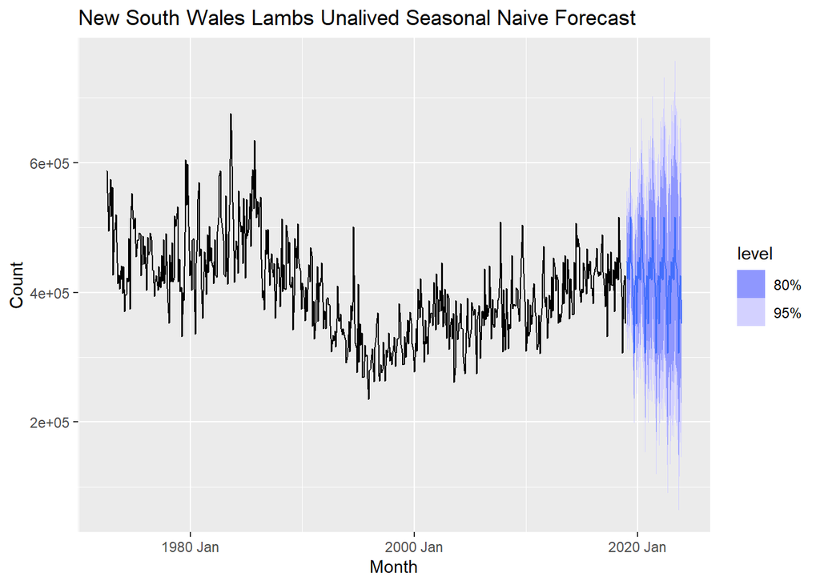

```r
nsw_lambs %>%
  model(Snaive = SNAIVE(Count)) %>%
  forecast(h = "5 years") %>%
  autoplot(nsw_lambs) +
  labs(title = "New South Wales Lambs Unalived Seasonal Naive Forecast")
```

The above forecast for NSW Lambs from `aus_livestock` was created using `SNAIVE(y)`. Just like the series before this data is best predicted with seasonality in mind. The confidence interval can also account for any upward or downward fluctuation just like before.

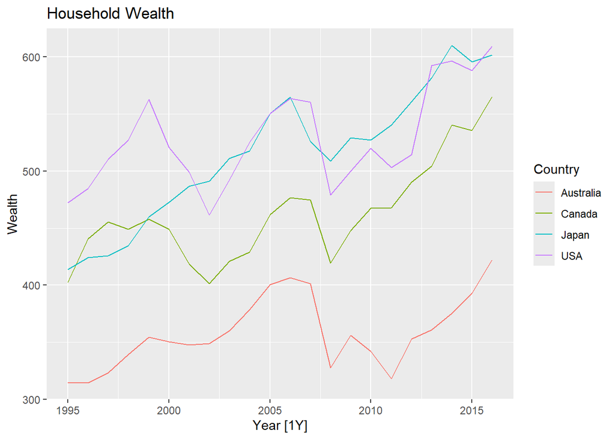

```r
hh_wealth <- hh_budget %>%
  filter(!is.na(Wealth)) %>%
  select(Wealth)

autoplot(hh_wealth) +
  labs(title = "Household Wealth")
```

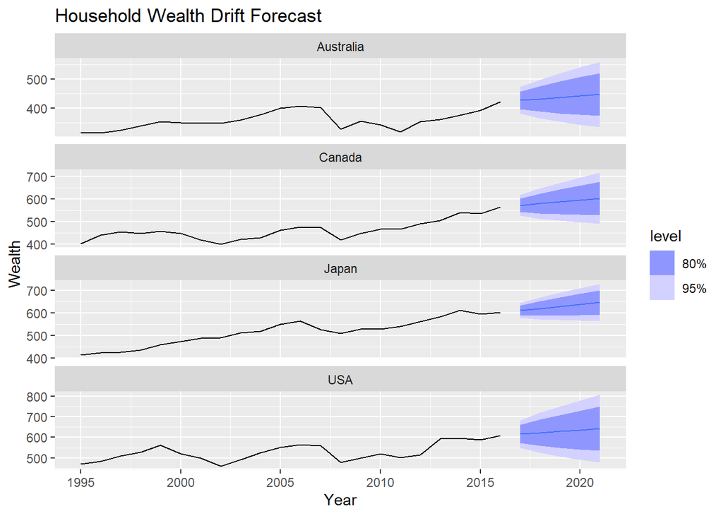

```r
hh_wealth %>%
  model(Drift = RW(Wealth ~ drift())) %>%
  forecast(h = "5 years") %>%
  autoplot(hh_wealth) +
  labs(title = "Household Wealth Drift Forecast")
```

The above forecast for Household wealth from `hh_budget` was created using `RW(y ~ drift())`. The series shows little to no seasonality and each country has a clear positive trend regardless of some fluctuation between the years 1999-2002 and 2007-2008.

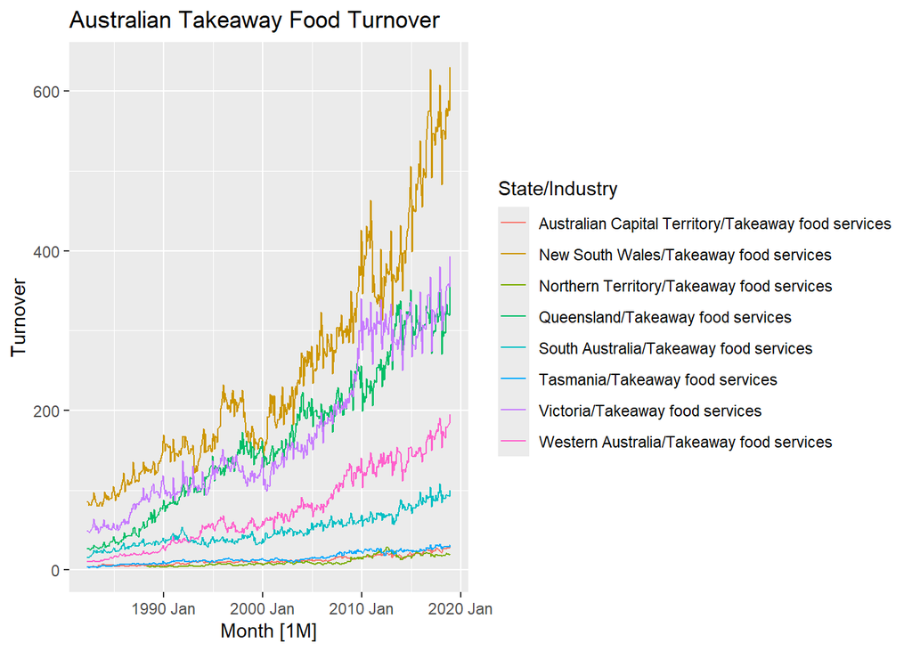

```r
takeaway <- aus_retail %>%
  filter(!is.na(Turnover)) %>%
  filter(Industry == "Takeaway food services")

autoplot(takeaway) +
  labs(title = "Australian Takeaway Food Turnover")
```

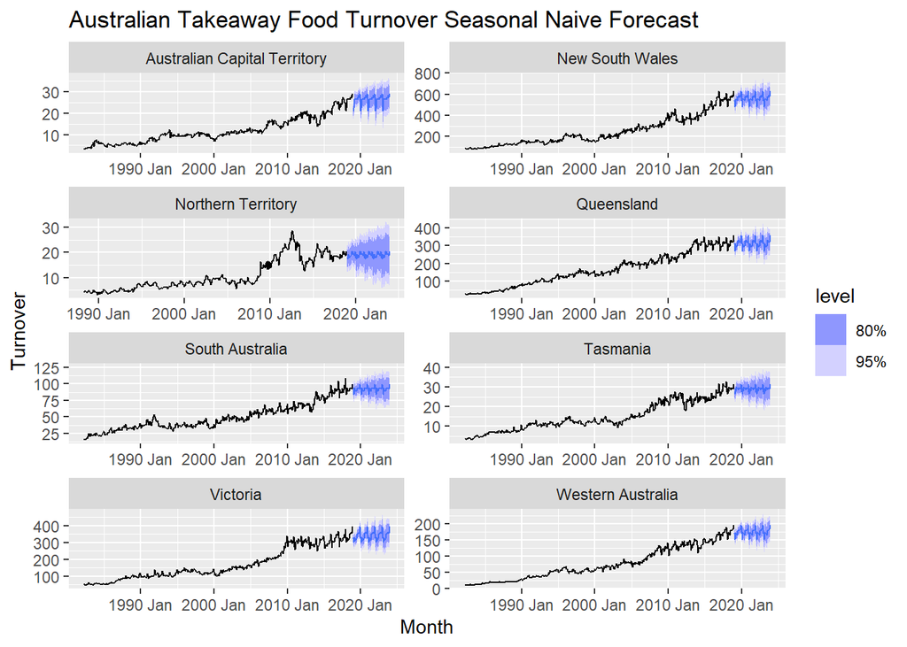

```r
takeaway %>%
  model(Snaive = SNAIVE(Turnover)) %>%
  forecast(h = "5 years") %>%
  autoplot(takeaway) +
  labs(title = "Australian Takeaway Food Turnover Seasonal Naive Forecast") +
  facet_wrap(vars(State), scales = "free", ncol = 2, nrow = 4)
```

The above forecast for Australian takeaway food turnover from `aus_retail` was created using `SNAIVE(y)`. The turnover data for each region of Australia shows clear seasonality even with a slightly upward trend this can easily be accounted for through the confidence intervals for each respective graph.

## Exercise 2

Use the Facebook stock price (data set gafa_stock) to do the following:

Produce a time plot of the series. Produce forecasts using the drift method and plot them. Show that the forecasts are identical to extending the line drawn between the first and last observations. Try using some of the other benchmark functions to forecast the same data set. Which do you think is best? Why?

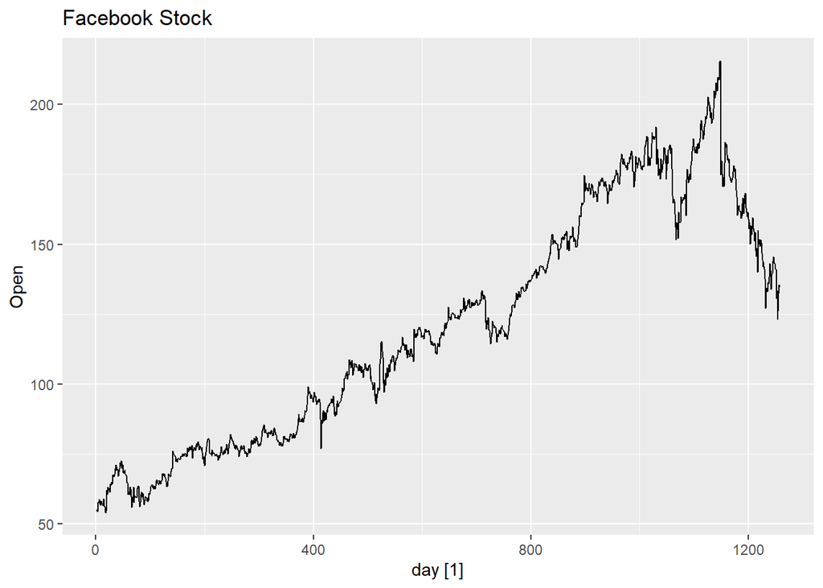

```r
fb_stock <- gafa_stock %>%
  filter(Symbol == "FB") %>%
  mutate(day = row_number()) %>%
  update_tsibble(index = day, regular = TRUE)

autoplot(fb_stock) +
  labs(title = "Facebook Stock")
```

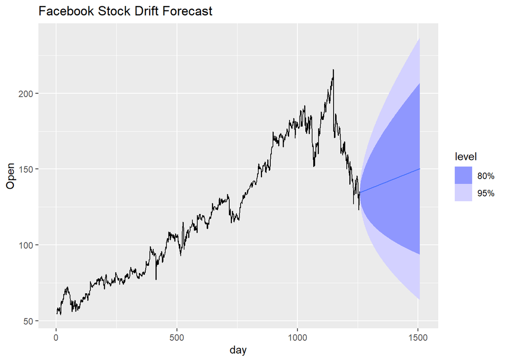

```r
fb_stock %>%
  model(Drift = RW(Open ~ drift())) %>%
  forecast(h = 250) %>%
  autoplot(fb_stock) +
  labs(title = "Facebook Stock Drift Forecast")
```

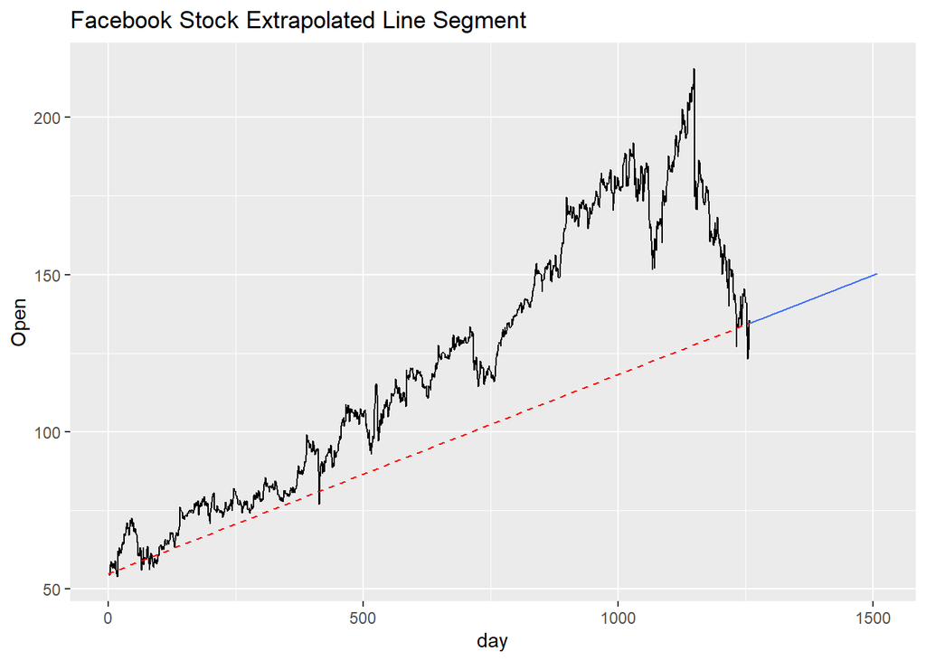

```r
fb_stock %>%
  model(Drift = RW(Open ~ drift())) %>%
  forecast(h = 250) %>%
  autoplot(fb_stock, level = NULL) +
  geom_segment(aes(x = min(day), y = Open[which.min(day)],
                   xend = max(day), yend = Open[which.max(day)]),
               color = "red", linetype = "dashed") +
  labs(title = "Facebook Stock Extrapolated Line Segment")
```

In order to show that the drift forecast is identical to extending the line drawn between the first and last observation, a second plot was created using `geom_segment` that drew a visible dashed line between the first and last points of the graph. As can be seen, the drift forecast is a clear continuation of this line.

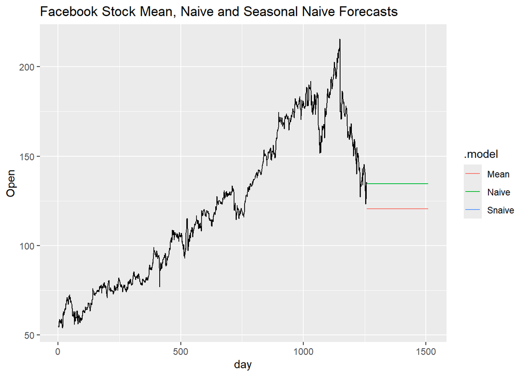

```r
fb_stock %>%
  model(Mean = MEAN(Open),
        Naive = NAIVE(Open),
        Snaive = SNAIVE(Open)) %>%
  forecast(h = 250) %>%
  autoplot(fb_stock, level = NULL) +
  labs(title = "Facebook Stock Mean, Naive and Seasonal Naive Forecasts")
```

When using some of the other benchmark functions to forecast the same data set, the naive technique seems to have had the best results. This statement, of course, should be taken with a grain of salt since the forecast extends all the way to 250 from the last data point. With this in mind, the naive forecast can hold true for a good few days but will then begin to deviate from the true value. Still, a naive forecast does perform better when compared to mean and seasonal naive forecasts.